# Final Project Report

### Density plots of Scores

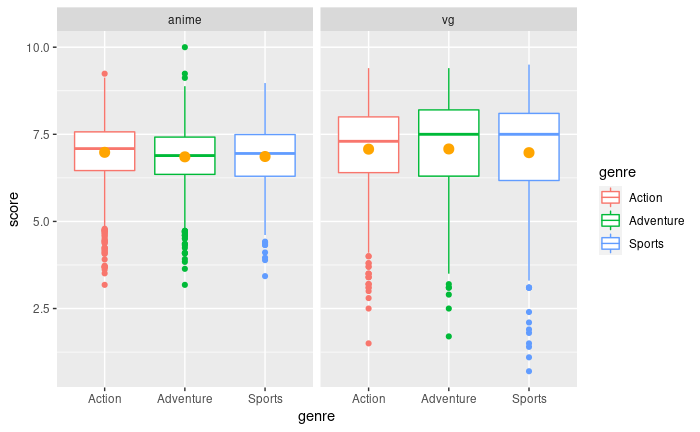

```r
popeverything <-
  bind_rows(popanime, popvgs)

popeverything %>%
  ggplot(aes(y = score, x = genre)) +
  geom_boxplot(aes(color = genre)) +
  facet_wrap( ~ type) +
  stat_summary(fun.y=mean, geom="point", shape=20, size=5, color="orange")
```

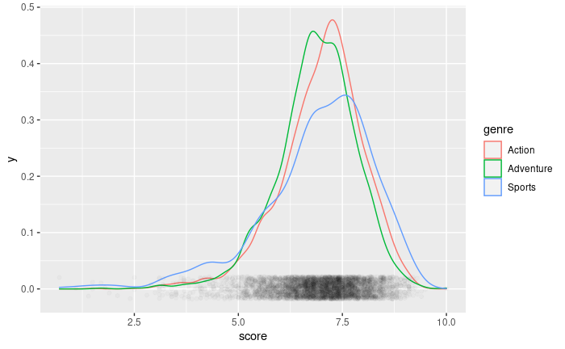

```r
popeverything %>%
ggplot(aes(x = score, group = genre)) +
  geom_density(alpha = 0.75, aes(color = genre)) +
  geom_point(alpha = 0.02, aes(y = 0.002),
             position = position_jitter(height = 0.02))
```

# Conclusions and Challenges

### Conclusions

Through the boxplots and the density plot it is clear that user scores are very consistent across genres for both anime and video games. While video games have a slightly higher median score than anime, they are still very close. I expected some more deviation between the two since the mediums can be so different and are enjoyed differently, but there could be multiple factors as to why scores are similar. It would be interesting to compare these observations to different entertainment mediums such as movies, TV shows, or plays to see if this trend persists. If the trend did persist it could just be a general trend across all entertainment which would be an interesting find.

### Challenges

One challenge I faced during this project was use of multiple topics from class. I overcame this by finding a way to use both a loop and regular expression to remove blank character strings from the vgs data frame. Writing the loop took a while because I had some trouble transferring how the loop worked in my head to actual code. I also had some challenges with RStudio Server while working on this project. When I first tried combining the data frames something went wrong which caused the project to keep crashing. I thought it was a problem with Rstudio Server, but after waiting for a while the problem kept happening. When I removed the bad code everything was fixed and I wa able to rewrite it correctly.